# Part II - (Characteristics of Loanstatus)

## by (Israel Joseph)

## Investigation Overview

In this analysis process, i would be looking into the characteristics of loan status ( default and Non-default) and how they behave among other features like Term, Occupation, DebtToIncomeRatio, BorrowerRate, Listing_category, Listing_category, ProsperRating, ProsperScore and IsBorrowerHomeowner

## Dataset Overview

The main data set contains 113,937 loans with 81 variables but the data that we would be working with contains 50650 loans and 14 variables that includes; ListingNumber, Term, Occupation, DebtToIncomeRatio, BorrowerRate, Listing_category, Listing_category, ProsperRating, ProsperScore IsBorrowerHomeowner, LoanOriginationDate EmploymentStatus, LoanOriginalAmount, IncomeRange and LoanStatus. about half of the data set were removed due to inconsistencies or missing information and also due to the fact the will be focusing on loanstatus that have defaulted those that havent so loans with the loanstatus of 'current' was removed

## The Distribution of the Loan Status feature.

The distribution of the loan status feature shows that borrowers that are Non-default(1) are much in numbers with about values greater than 30000 while those that defaulted(0) were below 20000

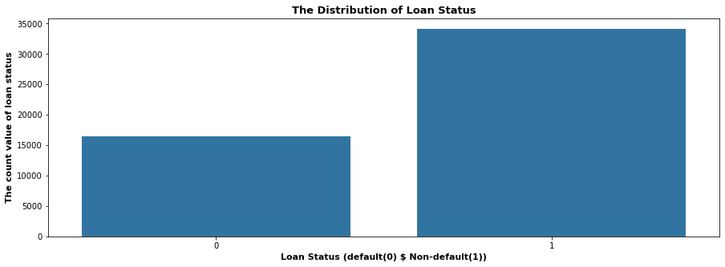

## The distribution of loan terms

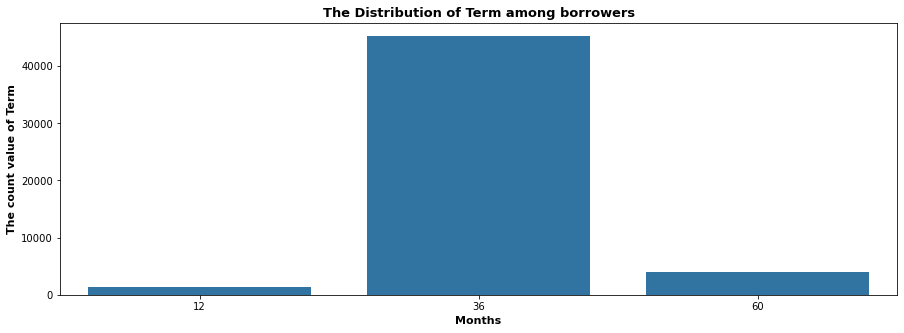

## The proper score distribution

Most of the borrowers a prosper score within 5 to 9 with 8 being the highest and suprisely those with the best prosper score (11) were very few and are below 500

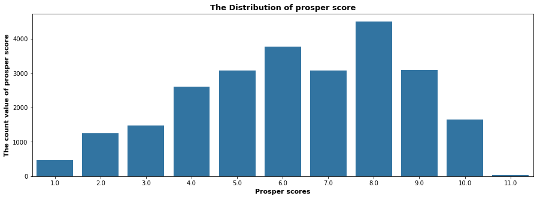

## Relationship between loan status and loan term

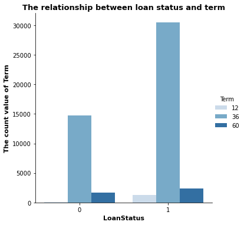

## The distribution of proper score and borrowers rate by loan status

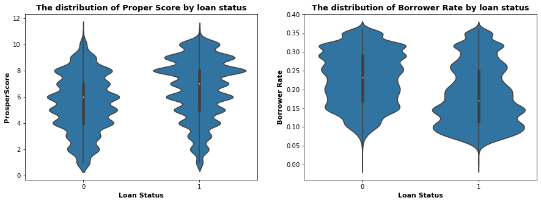

## Relationship between borrower rate, prosper score amd loan status

The borrower rate for both the default(0) and Non-default(1) decreases progressively as the prosper score increases. This visual also shows that borrowers that default(0) have higher borrowers rate than those that are Non-default(1) as it decreases progressively.

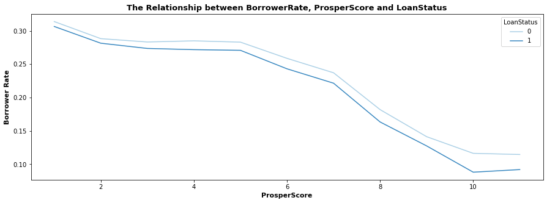

## The average debt to income ratio relationship between income range and loan status

Well the debt income ratio (DTI) which is the percentage of a consumers(borrower) mothly gross income that goes toward paying depth. From the analysis, it shows that unemployed borrowers(Not employed) that have defaulted(0) had a very high debt to income ratio average above 4.5 which means non employed borrowers with high debt to income ratio would default

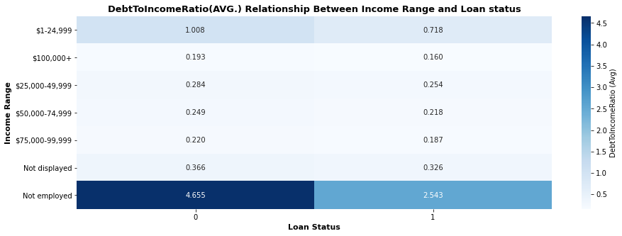